# Prueba de hipótesis y análisis de varianzas

GUALAPURO, Moisés

2023-04-25

## 0.1 Prueba de hipótesis

La data `orange` tiene 35 registros del crecimiento de árboles de naranja. Las variables son: el número de árbol, la edad en días a partir del 31 de diciembre de 1968 y la circunferencia medido en milímetros.

```r
data(Orange)
str(Orange)
```

```
## Classes 'nfnGroupedData', 'nfGroupedData', 'groupedData' and 'data.frame':   35 obs. of  3 variables:
##  $ Tree         : Ord.factor w/ 5 levels "3"<"1"<"5"<"2"<..: 2 2 2 2 2 2 2 4 4 4 ...
##  $ age          : num  118 484 664 1004 1231 ...
##  $ circumference: num  30 58 87 115 120 142 145 33 69 111 ...
##  - attr(*, "formula")=Class 'formula'  language circumference ~ age | Tree
##   .. ..- attr(*, ".Environment")=<environment: R_EmptyEnv>
##  - attr(*, "labels")=List of 2
##   ..$ x: chr "Time since December 31, 1968"
##   ..$ y: chr "Trunk circumference"
##  - attr(*, "units")=List of 2
##   ..$ x: chr "(days)"
##   ..$ y: chr "(mm)"
```

El número de árboles es de tipo factor y se tiene 5 árboles. La edad y el diámetro son de tipo numérico.

```r
summary(Orange)
```

```
##  Tree       age         circumference
##  3:7   Min.   : 118.0   Min.   : 30.0
##  1:7   1st Qu.: 484.0   1st Qu.: 65.5
##  5:7   Median :1004.0   Median :115.0
##  2:7   Mean   : 922.1   Mean   :115.9
##  4:7   3rd Qu.:1372.0   3rd Qu.:161.5
##        Max.   :1582.0   Max.   :214.0
```

## 0.2 Visualización preliminar

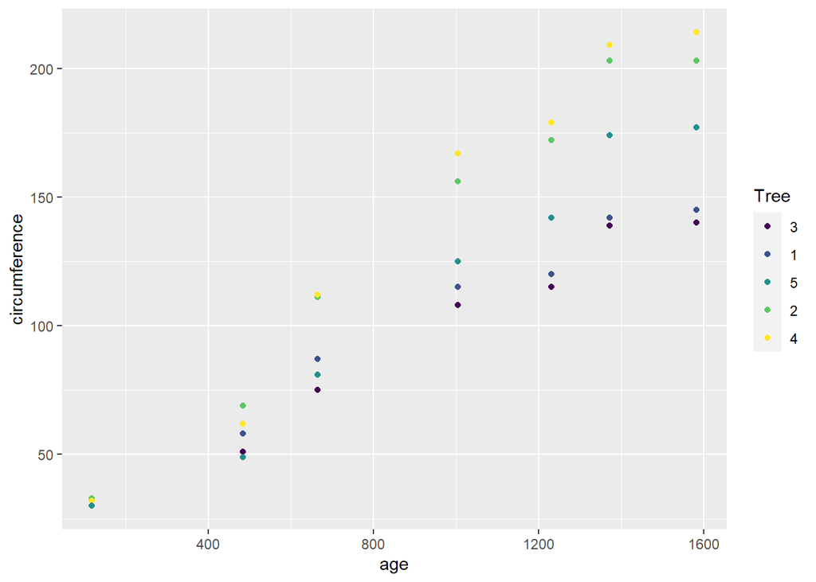

```r
library(ggplot2)
ggplot(data = Orange, aes(x = age, y = circumference,
                          col = Tree)) +
  geom_point()
```

La figura muestra que a medida que pasa el tiempo (edad) el diámetro de los árboles incrementa. El diámetro de los árboles 2 y 4 es mayor que la de los árboles 1 y 3.

## 0.3 Planteamiento de la Hipótesis

La hipótesis nula (H0) es aquella donde se espera que no exista efecto. Es la más fácil de contradecir.

$H_{01}$: La edad del árbol no incide en el tamaño del diámetro. $H_{02}$: Los árboles tienen el mismo diámetro a medida que pasa el tiempo.